# Supervised Learning I

Benchmarking with mlr3

# Goal

We will go beyond resampling single learners. We will learn how to compare a large number of different models using benchmarking. In this exercise, we will not show you how to tune a learner. Instead, we will compare identical learners with different hyperparameters that are set manually. In particular, we will learn how to set up benchmarking instances in `mlr3`.

# German Credit Data

We create the task as for the resampling exercise: Again, we make us of our work horse: The German Credit Data set.

```r
library(mlr3verse)
task = tsk("german_credit")
set.seed(2)
```

# Exercise: Benchmark multiple learners

We are going to compare a range of different KNN models ranging from a $k$ of 3 to 30. Furthermore, we want to assess the performance of a logistic regression.

## Create the learners

Create a logistic regression learner and many KNN learners. You should cover all KNNs with a $k$ between 3 and 30. Save all learners in a list. Give the KNN learners an appropriate `id` that reflects their $k$.

**Show Hint 1:**

Use the `lapply` function or a for-loop to create the list of learners with $k$ between 3 and 30. Don’t forget to also include the logistic regression learner in your list (the `append` function might be helpful here to extend a created list). The `lrn` function has an argument `id` that can be used to change the name of the learner (here, you should give the KNN learners an appropriate `id` that reflects their value of $k$ to be able to distinguish the learners).

**Show Hint 2:**

To create a list of KNN learners, you can use this template: `lapply(..., function(i) lrn("classif.kknn", k = i, id = paste0("classif.knn", i))`

### Solution

**Click me:**

```r
log_reg = lrn("classif.log_reg")
knn = lapply(3:30, function(i) lrn("classif.kknn", k = i, id = paste0("classif.knn", i)))
lrns = append(log_reg, knn)
```

## Create the resampling

Create a 4-fold cross-validation resampling. Create a list that only contains this resampling (this is needed later for the `benchmark_grid` function).

**Show Hint:**

See the previous resampling use case.

### Solution

**Click me:**

```r
cv4 = list(rsmp("cv", folds = 4))
```

## Create a benchmarking design

To design your benchmark experiment consisting of tasks, learners and resampling technique, you can use the `benchmark_grid` function from `mlr3`. Here, we will use only one task and one resampling technique but multiple learners. Use the previously created task (german credit), learners (the list of many KNN learners and a single logistic regression learner) and resampling (4 fold CV) as input.

**Show Hint 1:**

Also make sure that the task is included in a list as the arguments of the `benchmark_grid` function requires lists as input.

**Show Hint 2:**

`benchmark_grid(...)`

### Solution

**Click me:**

```r
design = benchmark_grid(list(task), lrns, cv4)
```

## Run the benchmark

Now you still need to run all experiments specified in the design. Do so by using the `benchmark` function. This may take some time. (Still less than a minute.) Make sure to store the benchmark in a new object called `bmr` as you will reuse and inspect the benchmark result in the subsequent exercises.

**Show Hint 1:**

`bmr = benchmark(...)`

### Solution

**Click me:**

```r
bmr = benchmark(design)
```

## Evaluate the benchmark

Choose two appropriate metrics to evaluate the different learners performance on the task. Compute these metrics and also visualize at least one of them using the `autoplot` function.

**Show Hint 1:**

The previously stored benchmark object has a method `$aggregate(...)` just like the objects created with the `resample` function from the previous use case.

**Show Hint 2:**

`autoplot(..., measure = msr(...))`

### Solution

**Click me:**

In case of a credit use case the false negative rate may be interesting to study next to the accuracy.

```r
res = bmr$aggregate(measures = c(msr("classif.fn"), msr("classif.acc")))
head(res)
```

```
##       nr       task_id      learner_id resampling_id iters classif.fn classif.acc
##    <int>        <char>          <char>        <char> <int>      <num>       <num>
## 1:     1 german_credit classif.log_reg            cv     4      26.00       0.750
## 2:     2 german_credit    classif.knn3            cv     4      33.00       0.692
## 3:     3 german_credit    classif.knn4            cv     4      33.00       0.692
## 4:     4 german_credit    classif.knn5            cv     4      24.00       0.712
## 5:     5 german_credit    classif.knn6            cv     4      23.25       0.712
## 6:     6 german_credit    classif.knn7            cv     4      23.25       0.712
## Hidden columns: resample_result
```

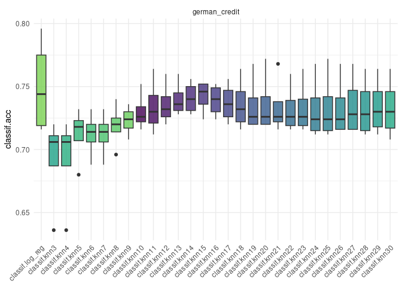

```r
autoplot(bmr, measure = msr("classif.acc"))
```

## Interpret the results

Interpret the plot. Which $k$ seems to work well given the task? Would you prefer a logistic regression over a KNN learner?

### Solution

# Extra: Parallelize your efforts

Benchmarking is **embarassingly** parallel. That means it is very easy to run the experiments of the benchmarking on different machines or cores. In many cases (not all!), this can significantly speed up computation time. We recommend to do this using the `future::plan` function when paralellizing `mlr3` benchmarks.

**Show Hint 1:**

**Show Hint 2:**

```r
library(future)
plan(multisession)
# your code
plan(sequential)
```

### Solution

**Click me:**

```r
# load the packages
library(mlr3)
library(future)
library(future.apply)

# parallel plan
plan(multisession)
set.seed(100) # it is good practice to set a seed before
bmr_par = benchmark(design)
plan(sequential)
```

# Summary

We learnt how to set benchmark in `mlr3`. While we only looked at a single task and a single resampling, the procedure easily applies to more complex benchmarks with many tasks. Additionally, we learnt how to understand benchmark results. Last but not least, you may have parallelized your benchmark if you still had some time left.